# Ch1 Getting Started

SOCI6630 Analysis and Interpretation of Sociological Data II

Before we get started, make sure you install R or R studio in your laptop or computer. Check the R sources website to get the download links.

#### Difference of R and R Studio:

1. **R**

   A free, open-sourced, integrated suite of software for data manipulation, calculations, graphical displays.
2. **R Studio**
   - `Script`: programs
   - `Console`: prompt
   - `Objects`: active in current session
   - tabs for help, graphs, etc.

#### Some tips when programming in R:

1. **`#`, Comments in the Scripts**

   Use `#` if you want to make comments in the scripts and don’t want R to run it. It is the same as `*` in STATA.
2. **Get some helps**

   To use R’s help, use `help(__)` or `?__`. For example, to know how to use `pnorm` this command, type `help(pnorm)` or `?pnorm` in console pane.
3. **Develop your own Workflow Habit**
   - Align your codes - Not just for pretty codes, also for others to read your codes easily.
   - Brief and Clear objects’ names - Don’t get yourself in trouble. Set those objects brief but clear, then you don’t have to type a lot everytime you want to call the objects.
   - Type in Script - Console is only for temporary use. Develop the habit of code in scripts.

## 1.1 R Basics

### 1.1.1 Interacting with the Interpreter

Data analysis in R can proceed as an interactive dialogue with interpreter. We type an R command at the `>` prompt, press the `Enter` key, and the interpreter responds by executing the command and returning a result.

You can use your console as a calculators. You can run lines of code in the script pane, and you can also run lines in console.

**HOWEVER**, develop workflow habits of **creating documented scripts** rather than relying on coding in console.

There are some examples:

```r
# addition
2 + 3
# subtraction
-1
# multiplication
2 * 3
# division
2/3
# exponentiation
2^3
# several arithmetic operations
4^2 - 3 * 2
# square root
sqrt(256)
```

```
> [1] 5
```

```
> [1] -1
```

```
> [1] 6
```

```
> [1] 0.6666667
```

```
> [1] 8
```

```
> [1] 10
```

```
> [1] 16
```

All error messages appear in the console pane.

### 1.1.2 R Functions

In addition to the common arithmetic operators, R includes many of functions for mathematical operations, for statistical data analysis, for making graphs, and for many other purposes. There are built-in functions that already set by R, and custom-built functions that you can create anytime you want.

For example,

```r
# sine function, and pi value
sin(pi/2)
# natural log 100
log(100)
# log 100 with base 10
log(100, base = 10)
log10(100)
```

```
> [1] 1
```

```
> [1] 4.60517
```

```
> [1] 2
```

```
> [1] 2
```

### 1.1.3 Vectors and Variables

The simplest of the data structures is a numeric vector, or one-dimensional list of numbers. In R, an indicivdual number is really a vector with a single element. There are some simple ways to construct a vector:

#### 1. `c()` function

```r
c(1, 2, 3, 4)
```

```
> [1] 1 2 3 4
```

#### 2. `:` (sequence operator) and `seq()` function

```r
# integer sequence
1:4
```

```
> [1] 1 2 3 4
```

```r
4:1
```

```
> [1] 4 3 2 1
```

```r
-1:2
```

```
> [1] -1  0  1  2
```

```r
# sequence from 1 to 4, the default interval is 1
seq(1, 4)
```

```
> [1] 1 2 3 4
```

```r
# sequence from 2 to 8, specify the interval as 2
seq(2, 8, by = 2)
```

```
> [1] 2 4 6 8
```

```r
# sequence from 0 to 1, specify the interval as 0.1
seq(0, 1, by = 0.1)
```

```
>  [1] 0.0 0.1 0.2 0.3 0.4 0.5 0.6 0.7 0.8 0.9 1.0
```

```r
# sequence from 0 to 1, specify the number of elements as 11
seq(0, 1, length = 11)
```

```
>  [1] 0.0 0.1 0.2 0.3 0.4 0.5 0.6 0.7 0.8 0.9 1.0
```

#### 3. standard arithmetic operators and functions are applied to the whole vectors

```r
c(1, 2, 3, 4)/2
```

```
> [1] 0.5 1.0 1.5 2.0
```

```r
c(1, 2, 3, 4)/c(4, 3, 2, 1)
```

```
> [1] 0.2500000 0.6666667 1.5000000 4.0000000
```

```r
log(c(0.1, 1, 10, 100), 10)
```

```
> [1] -1  0  1  2
```

```r
# no warning
c(1, 2, 3, 4) + c(4, 3)
```

```
> [1] 5 5 7 7
```

```r
# produces warning
c(1, 2, 3, 4) + c(4, 3, 2)
```

```
> Warning in c(1, 2, 3, 4) + c(4, 3, 2): longer object length is not a
> multiple of shorter object length
```

```
> [1] 5 5 5 8
```

```r
# square root of the vector
x <- c(1, 2, 3, 4)
sqrt(x)
```

```
> [1] 1.000000 1.414214 1.732051 2.000000
```

You can also name the vector as any name you want:

```r
x <- c(1, 2, 3, 4)  #assignment
x  #print x
```

```
> [1] 1 2 3 4
```

`<-` (left-pointing arrow) is the assignment operator, `=` may also be used for assignment, except inside a function call, where `=` is exclusively used to specify arguments by name. Because reserving the equals sign for specification of function arguments leads to clearer and less error-prone R code, I encourage you to use the arrow for assignment, even where `=` is allowed.

Also, `->` (right-pointing arrow) is allowed.

#### 4. Summary of a vector

```r
x <- rnorm(100)
summary(x)
```

```
>     Min.  1st Qu.   Median     Mean  3rd Qu.     Max.
> -2.33400 -0.77220  0.04308 -0.03147  0.63450  2.15300
```

`rnorm(n, mean = 0, sd = 1)` is the function generates standard-normal random numbers. In the case above, we generate 100 standard-normal random numbers. `n` is the amount of random numbers you want to generate. Standard-normal distribution are setted by the defaults `mean=0` and `sd=1`. You can change the `mean` and `sd` to any value and generate the random numbers.

`summary()` is the function gives you minimum, maximum, median, first quartiles and third quartiles.

### 1.1.4 Nonnumeric Vectors

#### 1. character vector

```r
words <- c("To", "be", "or", "not", "to", "be")
words
```

```
> [1] "To"  "be"  "or"  "not" "to"  "be"
```

You can also use `paste()` to turn this vector into a single character string:

```r
paste(words)
```

```
> [1] "To"  "be"  "or"  "not" "to"  "be"
```

```r
paste(words, collapse = " ")  #combine all elements with space
```

```
> [1] "To be or not to be"
```

#### 2. logical vector

```r
vals <- c(TRUE, TRUE, FALSE, TRUE)
vals
```

```
> [1]  TRUE  TRUE FALSE  TRUE
```

You can also use capitalized `T` and `F` to express `TRUE` and `FALSE`. Functions are available for working with logical vectors. If we use logical values in arithmetic, R treats `FALSE` as a zero and `TRUE` as a one.

```r
!vals
```

```
> [1] FALSE FALSE  TRUE FALSE
```

```r
sum(vals)  # Then this is equivalent to the amount of TRUE statement
```

```
> [1] 3
```

### 1.1.5 Indexing Vectors

If we wish to access only one of the elements of a vector, we can specify the index of the element within square brackets `[ ]`.

```r
x[12]  # 12th element
words[2]  # 2nd element
vals[3]  # 3rd element
```

```
> [1] -0.7175381
```

```
> [1] "be"
```

```
> [1] FALSE
```

You can also specify a vector of indices:

```r
x[6:15]
```

```
>  [1]  0.4347239 -1.3395208 -1.6615006 -1.4225865 -0.5814512  2.1533665
>  [7] -0.7175381 -0.2262069 -1.7041969  0.2272102
```

```r
x[c(1, 4, 5)]
```

```
> [1]  0.3688215  0.5341588 -0.1070404
```

Negative indices cause the corresponding values of the vector to be omitted:

```r
x[-(11:100)]  # omit elements 11 through 100
```

```
>  [1]  0.3688215 -0.1173627  1.4573333  0.5341588 -0.1070404  0.4347239
>  [7] -1.3395208 -1.6615006 -1.4225865 -0.5814512
```

A vector can also be indexed by a logical vector of the same length.

Logical values frequently arise through the use of **comparison operators**:

| Command | Meanings |
| --- | --- |
| == | equals |
| != | not equals |
| <= | less than or equals |
| < | less than |
| > | greater than |
| >= | greater than or equals |

`==` double-equals sign is used for testing equality.

Logical values may also be used in conjunction with the **logical operators**:

| Command | Meanings |
| --- | --- |
| & | and |
| `\|` | or |

There are some examples:

```r
1 == 2
```

```
> [1] FALSE
```

```r
1 != 2
```

```
> [1] TRUE
```

```r
1 < 1:3
```

```
> [1] FALSE  TRUE  TRUE
```

```r
3:1 > 1:3
```

```
> [1]  TRUE FALSE FALSE
```

### 1.1.6 User-Defined Functions

We can also create our own function:

```r
myMean <- function(x) {
    sum(x)/length(x)
}
myMean(x)  # x is rnorm(100), myMean() is equivalent to mean() here
```

```
> [1] -0.03146516
```

### 1.1.8 When Things Go Wrong

- Don’t worry too much about generating errors. R is an interactive system that you can proceed step by step, and fix mistakes as you go. R is also forgiving in that it is designed to restore the workspace to its previous state when a command results in an error.
- If you are unsure whether a command is properly formulated or whether it will do what you intend, try it out and carefully examine the result. You can often debug commands by trying them on a scaled-down problem with an obvious answer.
- When you do generate an error, don’t panic! Read the error or warning message carefully. Although some R error messages are cryptic, others are informative, and it is often possible to figure out the source of the error from the message. Some of the most common errors are merely typing mistakes. (**Small Tip**: When you can’t understand what is the error talking about, just copy all the error message and paste it in Google! There must be someone else has the same question as yours!)
- Sometimes, however, the source of an error may be subtle, particularly because an R command can generate a sequence of function calls of one function by another, and the error message may originate deep within this sequence. The `traceback` function, called with no arguments, provides information about the sequence of function calls leading up to an error. For example:

```r
myVar <- function(x) {
    sum((x - myMean(x))^2)/(length(x) - 1)
}
myVar(1:100)
var(1:100)  # check values

letters  # built-in object in R
myVar(letters)
```

```
> [1] 841.6667
```

```
> [1] 841.6667
```

```
>  [1] "a" "b" "c" "d" "e" "f" "g" "h" "i" "j" "k" "l" "m" "n" "o" "p" "q"
> [18] "r" "s" "t" "u" "v" "w" "x" "y" "z"
```

```
> Error in sum(x): invalid 'type' (character) of argument
```

Type in `traceback()` in R to see what happened.

- Not all errors generate error messages. Indeed, the ones that do not are more pernicious, because you may fail to notice them. Always check your output for resonableness, and follow up suspicious results.
- If you need to interrupt the execution of a command, you may do so by pressing the `Esc` key, or by using the mouse to press the `Stop` button in the toolbar.

## 1.2 Duncan’s Occupational-Prestige Regression

In this section, we are ready to run a regression example. we will:

1. Read data from a file into an R data frame
2. Draw graphs to examine the data using both standard R functions and some of the specialized functions included in the `car` package
3. perform a linear least-squares regression analysis
4. check the adequacy of the preliminary regression model using a variety of diagnostic methods

Don’t feel frustrated if everything becomes complicated suddenly! You will repeatedly use all the things in this section. It must be crazy when you first meet them.

We will use the file (the dataset) `Duncan.txt` (Download it in official website [here](https://socialsciences.mcmaster.ca/jfox/Books/Companion/data.html).)

```
>            type income education prestige
> accountant prof     62        86       82
> pilot      prof     72        76       83
> architect  prof     75        92       90
> author     prof     55        90       76
> chemist    prof     64        86       90
> minister   prof     21        84       87
> professor  prof     64        93       93
> dentist    prof     80       100       90
> reporter     wc     67        87       52
> engineer   prof     72        86       88
```

- `type`: Type of occupation, `bc` is blue collar, `wc` is white collar, `prof` is professional or managerial
- `income`: Percentage of occupational incumbents in the 1950 U.S. Census who earned more than $3,500 per year (about $31,000 in 2008 U.S. dollars)
- `education`: Percentage of occupational incumbents in 1950 who were high school graduates (which, were we cynical, we would say is roughly equivalent to a PhD in 2008)
- `prestige`: Percentage of respondents in a social survey who rated the occupation as “good” or better in prestige

Duncan used a linear least-squares regression of `prestige` on `income` and `education` to predict the prestige levels of occupations for which the income and decuational levels were known but for which there were no direct prestige ratings. Duncan did not use occupational `type` in his analysis. Therefore, the predictive model is as follows:

$$\text{prestige} = \beta_0 + \beta_1(\text{income}) + \beta_2(\text{education})$$

### 1.2.1 Reading Data

Firstly, we have to set up the word directory we used. Once we set up the path to work directory, we don’t have to write the whole path to the file everytime when we are inputting the file.

1. (**By code, Easiest!**) Type in the code `setwd("your/path")`, then you are all set!
2. (**In R**) Click `Misc` -> `Change Word Directory` -> Select the directory you put your file
3. (**In R Studio**) Click `Session` -> `Set Work Directory` -> `Choose Directory` -> Select the directory you put your file

You can still type in the complete path of your file when you are inputting data! (Let me know if you meet any problem since my operation system is OS X not Windows.)

Then, since we have `.txt` file, we will use `read.table` function to read the data from the file into a data frame.

```r
Duncan <- read.table("Duncan.txt", header = TRUE)
summary(Duncan)
```

```
>    type        income        education         prestige
>  bc  :21   Min.   : 7.00   Min.   :  7.00   Min.   : 3.00
>  prof:18   1st Qu.:21.00   1st Qu.: 26.00   1st Qu.:16.00
>  wc  : 6   Median :42.00   Median : 45.00   Median :41.00
>            Mean   :41.87   Mean   : 52.56   Mean   :47.69
>            3rd Qu.:64.00   3rd Qu.: 84.00   3rd Qu.:81.00
>            Max.   :81.00   Max.   :100.00   Max.   :97.00
```

The `summary()` function we learned before will give you summary of each variables. Since variables `income`, `education`, and `prestige` are numeric variables, then the summary gives you the min., max., median, mean, 1st quartile, and 3rd quartile. However, since variable `type` is character variable, the summary gives you the amount of each level. That is why making sure the type of variables is important!

You can access the columns of the dataframe by using following three ways. For example, if you want to drag out the `prestige` column:

1. Use `$`

```r
Duncan$prestige
```

[output not shown]

2. Use `[ ]` and Specify the column name

```r
Duncan[, "prestige"]
```

```
>  [1] 82 83 90 76 90 87 93 90 52 88 57 89 97 59 73 38 76 81 45 92 39 34 41
> [24] 16 33 53 67 57 26 29 10 15 19 10 13 24 20  7  3 16  6 11  8 41 10
```

3. Use `attach()` to access all columns by names

```r
attach(Duncan)
prestige
```

```
>  [1] 82 83 90 76 90 87 93 90 52 88 57 89 97 59 73 38 76 81 45 92 39 34 41
> [24] 16 33 53 67 57 26 29 10 15 19 10 13 24 20  7  3 16  6 11  8 41 10
```

### 1.2.2 Examining Data

A sensible place to start any data analysis, including a regression analysis, is to examine the data using a variety of graphical displays.

#### 1. Histogram

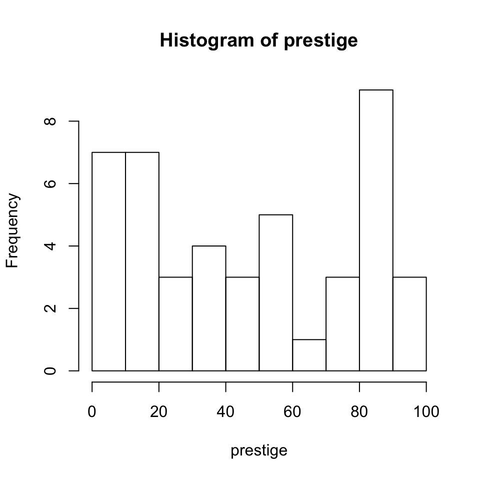

```r
hist(prestige)
```

The distribution of `prestige` appears to be bimodal, with observations stacking up near the lower and upper boundaries. Because `prestige` is a percentage, this behavior is not altogether unexpected–many occupations will either be lowe prestige, near the lower boundary, or high prestige, near the upper boundary, with fewer occupations in the middle. Variables such as this often need to be transformed, perhaps with a logit (log-odds) or similar transformation.

#### 2. Scatterplot Matrix

We should also examine the distirbutions of the predictor variables, along with the relationship between `prestige` and each predictor, and the relationship between the two predictors. The `pairs` function draws a **scatterplot matrix**.

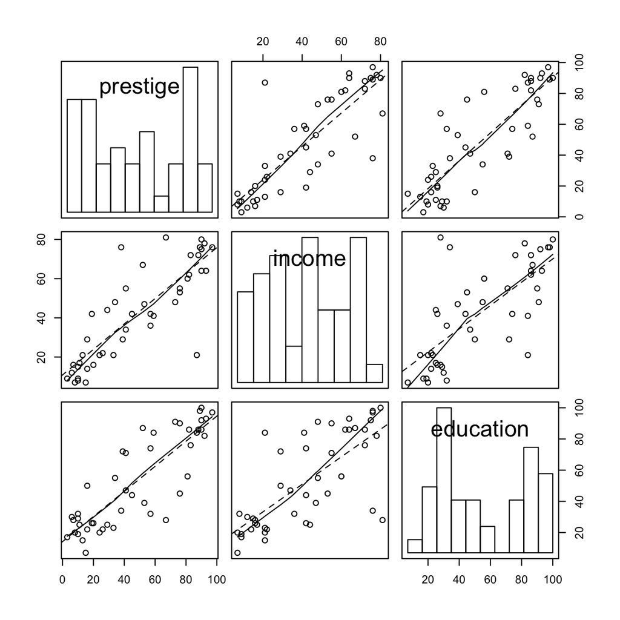

```r
pairs(cbind(prestige, income, education), panel = function(x,
    y) {
    points(x, y)
    abline(lm(y ~ x), lty = "dashed")
    lines(lowess(x, y))
}, diag.panel = function(x) {
    par(new = TRUE)
    hist(x, main = "", axes = FALSE)
})
```

Don’t panic! You can actually do all the things inside step by step though writing them together makes thing complicated but faster. Each steps are actually:

1. **`cbind`**: column-bind function constructs a three-column matrix from the vectors `prestige`, `income`, and `education`, as required by the `pairs` function.
2. **`panel`**: argument in `pairs` function that specifies a function that draws each off-diagonal panel of the scatterplot matrix. The function must have two arguments, which we call `x` and `y`, representing the horizontal and vertical variables in each plot. The panel function can be either a predefined function or anonymous function.
- **`points(x, y)`**: Plots the points
- **`abline(lm(y ~ x), lty="dashed")`**: Draws a broken line (specified by the line type `lty="dashed"`) with intercept and slope given by a linear regression of y on x, computed by `lm` (linear-model) function. The result returned by `lm` is passed as an argument to `abline`.
- **`lines(lowess(x, y))`**: Draws a solid line, the default line type, showing the nonparametric regression of `y` on `x`.

A quick recap, we can rewrite the first line as follows since we only exclude the first column here.

```r
cbind(prestige, income, education)
cbind(Duncan[, -1])
```

3. **`diag.panel`**: argument that tells `pairs` what to plot on the diagonal of the scatterplot matrix. The function supplied must take one argument (`x`), corresponding to the current diagonal variable:
- **`par(new=TRUE)`**: prevents the `hist` function from trying to clear the graph. In R, high-level plotting functions such as `plot()`, `hist()`, and `pairs()`, by default clear the current graphics device prior to drawing a new plot.
- **`hist(x, main="", axes=FALSE)`**: plots a histogram for `x`, suppressing both the main title and the axes.

### 1.2.3 Regression Analysis

Our plots don’t directly address the joint dependence of `prestige` on `education` and `income`. Then we next fit a linear least-squares regression to the data to get numerical summaries for the joint dependence of `prestige` on the two predictors:

```r
duncan.model <- lm(prestige ~ income + education)
duncan.model
```

```
>
> Call:
> lm(formula = prestige ~ income + education)
>
> Coefficients:
> (Intercept)       income    education
>     -6.0647       0.5987       0.5458
```

Because we attached the `Duncan` data frame, we can access the variables in it by name. If not, specify the data name at the end like this: `duncan.model <- lm(prestige ~ income + education, data = Duncan)`.

On the left of the tilde (`~`) is `prestige`, the response variable. On the right of the tilde is `income` and `education`, which are the predictor variables in the regression. Read the formula as “`prestige` is regressed on `income` and `education`.”

`summary()` will give you more information about the linear-model object:

```r
summary(duncan.model)
```

```
>
> Call:
> lm(formula = prestige ~ income + education)
>
> Residuals:
>     Min      1Q  Median      3Q     Max
> -29.538  -6.417   0.655   6.605  34.641
>
> Coefficients:
>             Estimate Std. Error t value Pr(>|t|)
> (Intercept) -6.06466    4.27194  -1.420    0.163
> income       0.59873    0.11967   5.003 1.05e-05 ***
> education    0.54583    0.09825   5.555 1.73e-06 ***
> ---
> Signif. codes:  0 '***' 0.001 '**' 0.01 '*' 0.05 '.' 0.1 ' ' 1
>
> Residual standard error: 13.37 on 42 degrees of freedom
> Multiple R-squared:  0.8282,  Adjusted R-squared:   0.82
> F-statistic: 101.2 on 2 and 42 DF,  p-value: < 2.2e-16
```

Both `income` and `education` have highly statistically significant, and rather large, regression coefficients. R writes vecry small and very large numbers in scientific notation. For example, `1.1e-05` is to be read as $1.1 \times 10^{-5}$, or $0.000011$, and `2e-16` is $2 \times 10^{-16}$, which is effectively zero.

### 1.2.4 Regression Diagnostics

Assuming that the regression in the rpevious section adequately summarizes the data does not make it so. It is therefore wise after fitting a regression model to check the fit using a variety of graphical and numeric procedures. The standard R distribution includes some facilities for regression diagnostics, and the **`car`** package augments these capabilities. Install this package easily by following commands:

```r
install.packages("car")
library(car)  # to check you have this package in your R
# If library runs successfully, then it means you already
# installed the package!
```

#### 1. Histogram of Studentized Residuals

A studentized residual is the division of a residual by an estimate of its standard deviation. `rstudent` function can easily give you the these residuals. Then we create a histogram of studentized residuals:

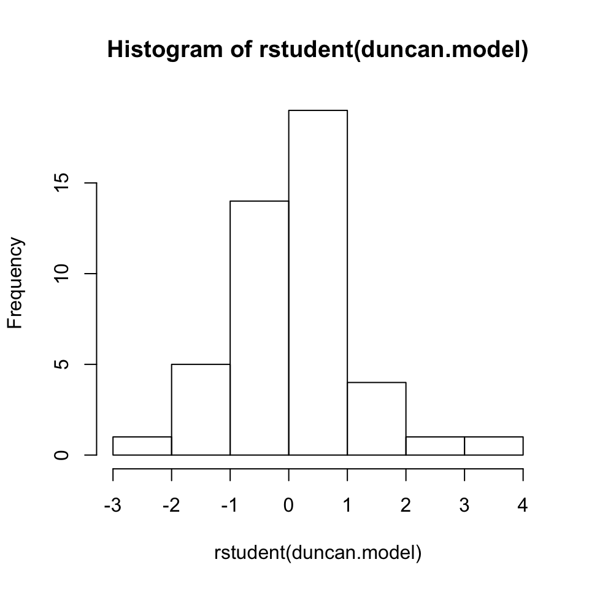

```r
hist(rstudent(duncan.model))
```

#### 2. QQPlot for Studentized Residuals

Create quantile-comparison plots to test the normality of our model:

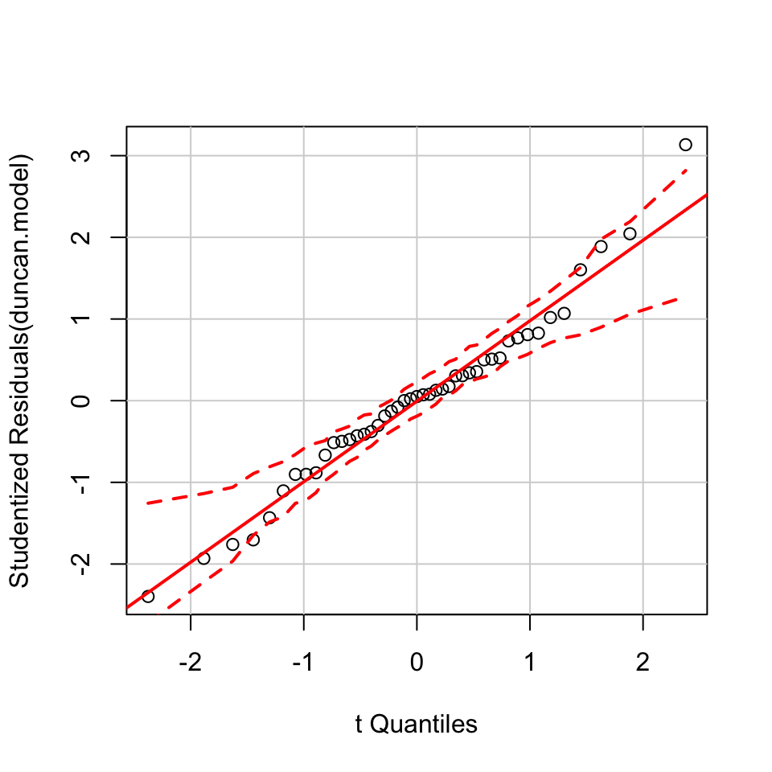

```r
library(car)
qqPlot(duncan.model)
```

#### 3. Index Plots of Cook’s distance and hat-values

To check for high-leverage and influential observations by plotting hat-values and cook’s distances against the obersvation indices:

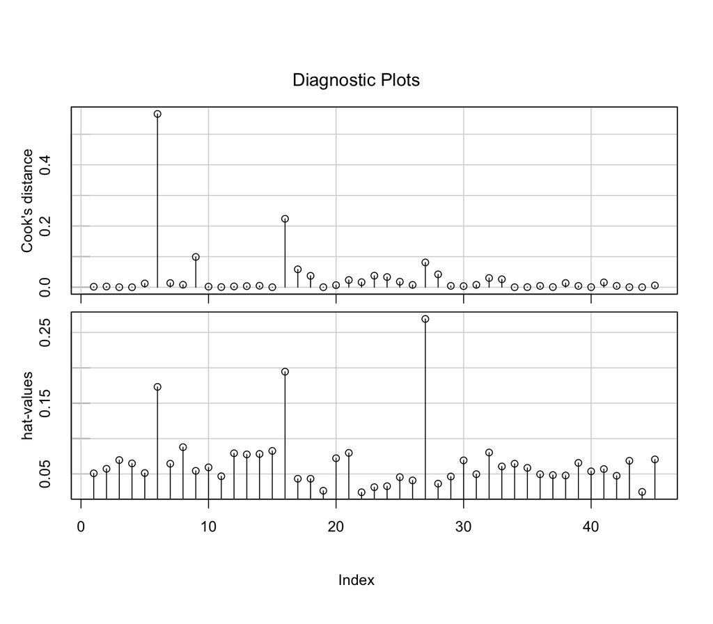

```r
library(car)
influenceIndexPlot(duncan.model, vars = c("Cook", "hat"))
```

Without using `car` package, knows that you can obtain all of these by `plot()` function. (But it uses regular residual not studentized residuals.) If you put a linear-model object in `plot()` function, it gives you four graphs. You can also specify which graph you want.

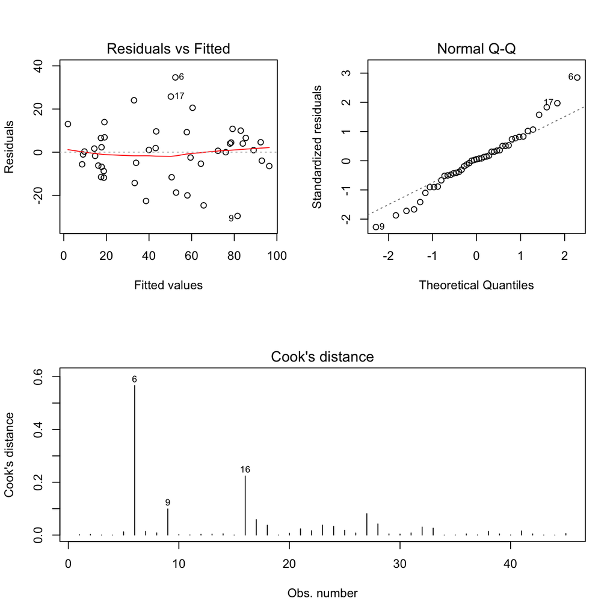

```r
layout(matrix(c(1, 2, 3, 3), 2, 2, byrow = T))
plot(duncan.model, which = c(1, 2, 4))  # Specify these three graphs
```

#### 4. Added-variable Plots

Because the observations in a regression can be jointly as well as individually influential, we also examine added-variable plots for the predictors, using `avPlots` function in the `car` package.

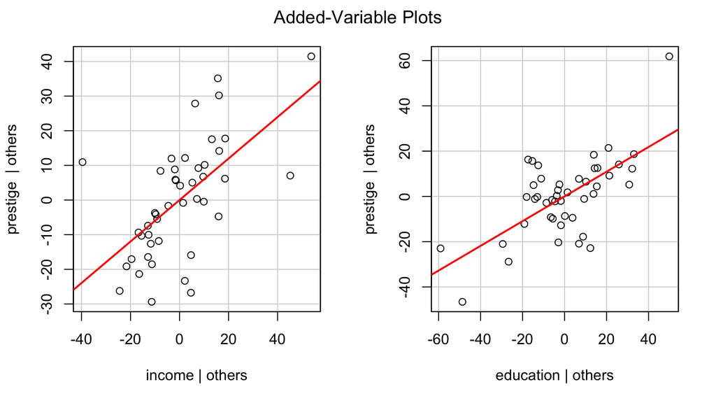

```r
library(car)
avPlots(duncan.model, id.cex = 0.75)
```

#### 5. Component-plus-residual plots

`crPlots` function, also in `car` package, generate component-plus-residual plots for two predictor variables.

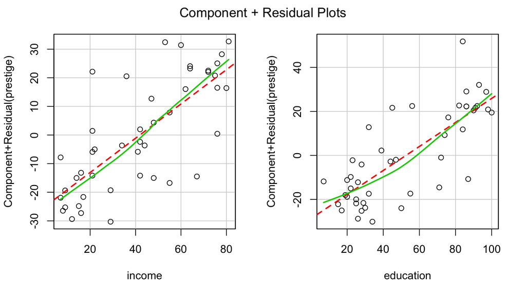

```r
library(car)
crPlots(duncan.model, span = 0.7)
```

#### 6. Spread-level Plot

To check whether the size of the residuals changes systematically with the fitted values, using the `spreadLevelPlot` function in the `car` package.

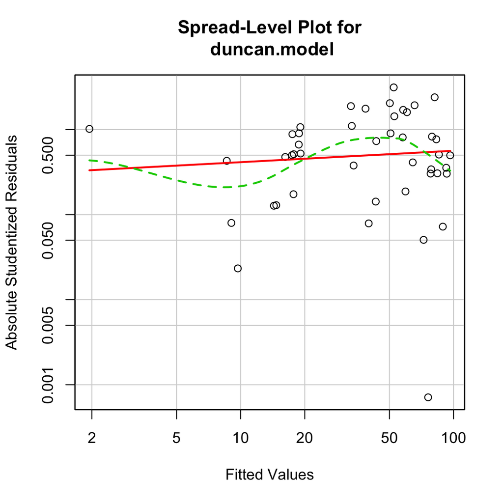

```
>
> Suggested power transformation:  0.8653151
```

```r
library(car)
spreadLevelPlot(duncan.model)
```

#### 7. Score Tests for nonconstant variance

To check the association of residual spread with the fitted values and with any linear combination of the predictors.

```r
ncvTest(duncan.model)
```

```
> Non-constant Variance Score Test
> Variance formula: ~ fitted.values
> Chisquare = 0.3810967    Df = 1     p = 0.5370169
```

```r
ncvTest(duncan.model, var.formula = ~income + education)
```

```
> Non-constant Variance Score Test
> Variance formula: ~ income + education
> Chisquare = 0.6976023    Df = 2     p = 0.7055334
```

Both tests are far from statistically significant, indicating that the assumption of constant variance is tenable.

#### 8. Remove particular data points

Based on the influential-data diagnostics, remove the observations `minister` and `conductor` from the regression:

```r
summary(update(duncan.model, subset = -c(6, 16)))  # those two are #6 and #16 rows
```

```
>
> Call:
> lm(formula = prestige ~ income + education, subset = -c(6, 16))
>
> Residuals:
>     Min      1Q  Median      3Q     Max
> -28.612  -5.898   1.937   5.616  21.551
>
> Coefficients:
>             Estimate Std. Error t value Pr(>|t|)
> (Intercept) -6.40899    3.65263  -1.755   0.0870 .
> income       0.86740    0.12198   7.111 1.31e-08 ***
> education    0.33224    0.09875   3.364   0.0017 **
> ---
> Signif. codes:  0 '***' 0.001 '**' 0.01 '*' 0.05 '.' 0.1 ' ' 1
>
> Residual standard error: 11.42 on 40 degrees of freedom
> Multiple R-squared:  0.876,   Adjusted R-squared:  0.8698
> F-statistic: 141.3 on 2 and 40 DF,  p-value: < 2.2e-16
```

## 1.4 Generic Functions and Their Methods

[Here](https://cran.r-project.org/doc/contrib/Short-refcard.pdf) is the R reference card of some basic commands.

The following table contains the basic commands that will be used in first five chapters.

| Method | R Functions |
| --- | --- |
| histogram | `hist()` |
| stem-and-leaf display | `stem()` |
| boxplot | `boxplot()` |
| scatterplot | `plot()` |
| time-series plot | `ts.plot()` |
| mean | `mean()` |
| quantiles | `quantile()` |
| extremes | `range()` |
| variance | `var()` |
| standard deviation | `sd()` |
| covariance matrix | `var()`, `cov()` |
| correlations | `cor()` |
| **normal distribution** |  |
| — density | `dnorm()` |
| — distribution | `pnorm()` |
| — quantiles | `qnorm()` |
| — random numbers | `rnorm()` |
| **t distribution** |  |
| — density | `dt()` |
| — distribution | `pt()` |
| — quantiles | `qt()` |
| — random numbers | `rt()` |
| **F distribution** |  |
| — density | `df()` |
| — distribution | `pf()` |
| — quantiles | `qf()` |
| — random numbers | `rf()` |
| **binomial distribution** |  |
| — probabilities | `dbinom()` |
| — distribution | `pbinom()` |
| — quantiles | `qbinom()` |
| — random numbers | `rbinom()` |
| simple regression | `lm()` |
| multiple regression | `lm()` |
| analysis of variance (ANOVA) | `aov()`, `lm()`, `anova()` |
| contingency tables | `xtabs()`, `table()` |
| generating random samples | `sample()`, `rnorm()` |
| t-tests for means | `t.test()` |
| tests for proportions | `prop.test()`, `binom.test()` |
| chi-square test for independence | `chisq.test()` |
| various nonparametric tests | `friedman.test()`, `kruskal.test()`, `wilcox.test()` |